# Quiz 3

2023-12-12

## 시험시간: 2023년 12월 12일 13:10 ~ 14:10

## 제출: Html, Rmd 파일을 .zip으로 압축해 etl에 제출

#### 주의사항

- 전자기기(휴대폰 등)나 메신저(메일, 카톡 등)는 시험 중 절대로 사용할 수 없음. 사용이 적발 시 부정행위로 간주해 바로 퇴실조치.
- 시간 초과로 인해 제출하지 못하는 경우 책임은 수강생 본인에게 있음. 마감 시간 까지 문제를 푸는 것이 아닌, Knit과 etl 제출까지 완료해야 하므로 꼭 마지막 5~10분은 제출 준비 할 것.

```r
library(tidyverse)
library(quantmod)
library(lubridate)
```

### Q1. 콜라츠 추측은 임의의 자연수가 다음 함수를 여러번 거치면 항상 1이 된다는 추측이다. 예를 들어, 6에서 시작한다면, 차례로 6, 3, 10, 5, 16, 8, 4, 2, 1 이 된다.

$$T(n)=\left\{\begin{array}{cc}
\frac{n}{2}, & \text { if } n \text { is even } \\
3 n+1, & \text { if } n \text { is odd }
\end{array}\right.$$

### 다음 조건에 따라 콜라츠 추측을 구현하는 함수를 만드시오.

- 조건 1. 함수의 input은 자연수로 하고 output은 모든 숫자(`number`)와 시행 횟수(`trial`)가 나오도록 한다. input이 자연수가 아닌 경우 에러 메세지를 출력하도록 한다.
- 조건 2. 반복문을 사용할 것.
- 조건 3. 함수를 구현한 뒤 `436712387`를 넣어 결과값을 저장하고 `tail`함수로 출력하시오. 또한 아래 그림과 같이 콜라츠 추측을 시각화하시오. 마지막 점의 시행 횟수와 숫자를 plot 상에 표시할 것.
- 조건 4. `100.5`를 함수에 넣어 에러 메세지를 출력하시오.

아래 그림은 500을 함수에 넣었을 때 나온 값의 예시

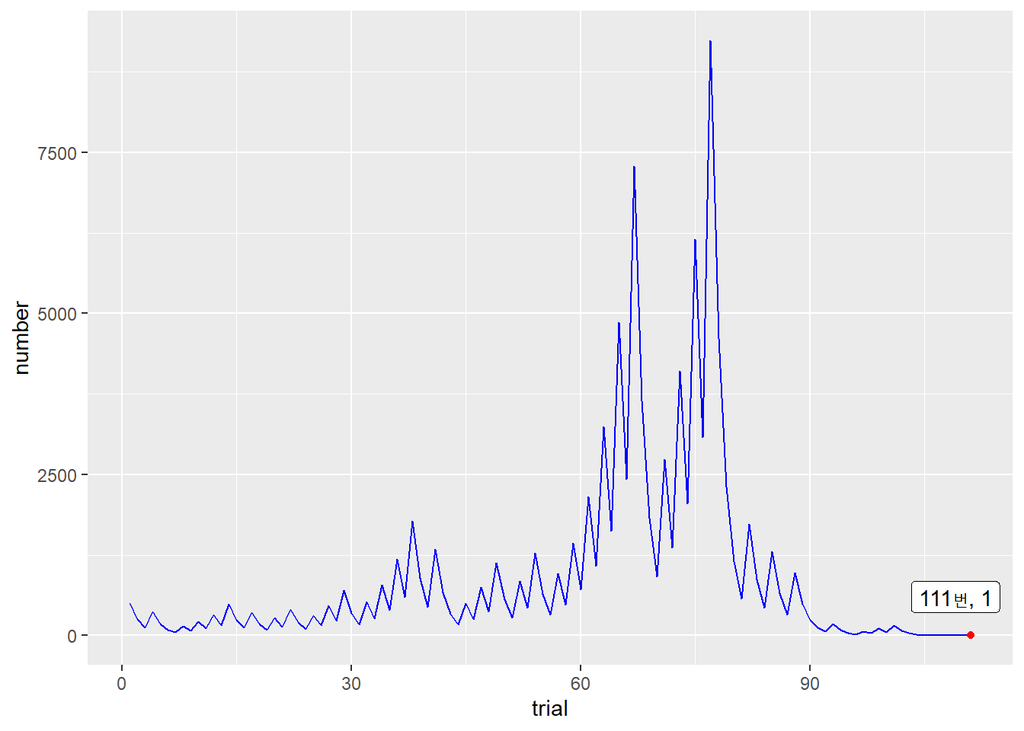

### A1.

```r
collatz = function(x){
  if((x %% 1 == 0) & (x > 0)){
  num = c(x)
  while(x != 1){
    if(x %% 2 == 0){
      x = x/2
    }
    else{
      x = 3*x+1
    }
    num = c(num, x)
  }
  return(data.frame(number = num, trial = seq(1, length(num), by = 1)))
  }
  else{return("Input is not a natural number.")}
}
collnum = collatz(436712387)
tail(collnum)
```

```
##     number trial
## 216     32   216
## 217     16   217
## 218      8   218
## 219      4   219
## 220      2   220
## 221      1   221
```

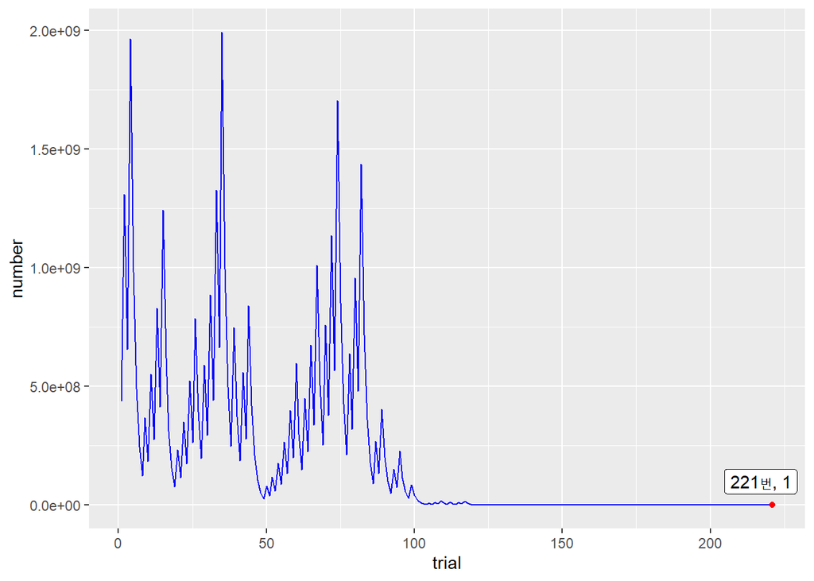

```r
ggplot(data = collnum) + geom_line(mapping = aes(x = trial, y = number), col="blue", linewidth = 0.5) +
  geom_point(data = collnum[nrow(collnum),], mapping = aes(x = trial, y = number), color = "#FF0000") +
  geom_label(data = collnum[nrow(collnum),], mapping = aes(x = trial, y = number, label = paste0(trial, "번, ", number)), nudge_x = -4, nudge_y = 100000000)
```

```r
collatz(100.5)
```

```
## [1] "Input is not a natural number."
```

### Q2. `lubridate::lakers` 는 08-09 시즌 LA 레이커스 농구팀의 시즌동안의 기록들이 들어있는 데이터이다.

- `date` : 경기 날짜
- `opponent` : 상대팀
- `game_type` : 홈 & 어웨이 경기
- `time` : 각 퀴터 남은시간
- `period` : 쿼터
- `etype` : 현재 경기 상황
- `team` : 현재 `etype` 을 하고 있는 팀
- `player` : `etype` 을 한 선수이름
- `result` : `etype` 의 `shot`,`free throw` 의 경우 성공여부
- `points` : 득점하였을 경우 득점양
- `type` : `etype` 의 좀더 세세한 정보

#### 2-1. LA 레이커스가 각 상대팀들과 대결할때 각 팀별로 넣은 평균득점을 알아보고자 한다. 상대팀에 따른 평균 득점을 시각화하시오.

- 조건 1. 평균득점 순서대로 나열되게 그리시오

#### 2-2. LA 레이커스에서 이번 시즌 자유투 시도를 누가 제일 많이 했는지를 알아보고자 한다. 자유투 시도 (etype = free throw) 횟수가 제일 많은 10명은 누구인가?

- 조건 1. 10명의 선수들을 자유투 시도 횟수와 함께 도표로 나타낼 것

#### 2-3. LA 레이커스의 경기별 득점양을 date 순서로 된 그래프로 나타내어라.

### A2

2-1.

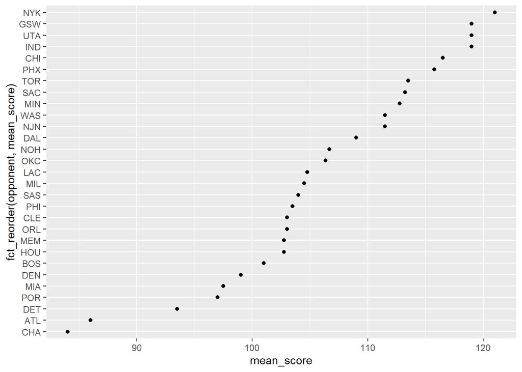

```r
lakers <-
  mutate_at(lubridate::lakers, vars(1, 2, 3, 5, 6, 7, 8, 9, 11), as_factor)

game_with_lakers <- count(lakers, date, opponent) %>%
  count(opponent)

total_score_lakers <- lakers %>%
  group_by(opponent, team) %>%
  summarise(score = sum(points), .groups = 'drop') %>%
  filter(team == "LAL")


final_lakers <-
  merge(total_score_lakers, game_with_lakers, by = c("opponent")) %>%
  mutate(mean_score = score / n)

ggplot(final_lakers, aes(mean_score, fct_reorder(opponent, mean_score))) +
  geom_point()
```

2-2.

```r
free_throw_player <-
  filter(lakers, team == "LAL", etype == "free throw")

free_throw_player %>%
  mutate(player = fct_lump(player, n = 10))  %>%
  count(player, sort = TRUE) %>%
  print()
```

```
##           player   n
## 1    Kobe Bryant 529
## 2      Pau Gasol 423
## 3     Lamar Odom 240
## 4   Andrew Bynum 207
## 5   Trevor Ariza 159
## 6   Derek Fisher 122
## 7  Jordan Farmar  75
## 8  Sasha Vujacic  70
## 9    Luke Walton  52
## 10         Other  51
## 11   Josh Powell  48
```

2-3.

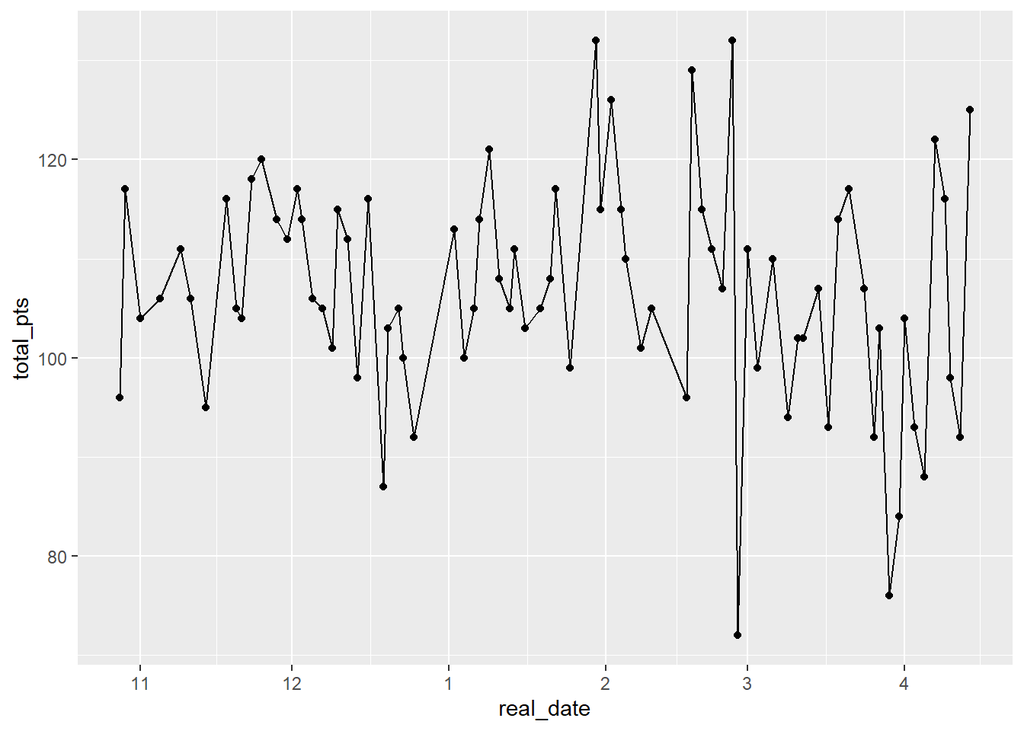

```r
lakers_with_date <- mutate(
  lakers,
  year = substr(lakers$date, 1, 4),
  month = substr(lakers$date, 5, 6),
  day = substr(lakers$date, 7, 8),
  real_date = make_date(year, month, day)
)

each_game_pts_of_lakers <- lakers_with_date %>%
  filter(team == "LAL") %>%
  group_by(real_date) %>%
  mutate(total_pts = sum(points)) %>%
  select(real_date, total_pts) %>%
  unique

each_game_pts_of_lakers %>%
  ggplot(aes(real_date, total_pts)) +
  geom_point() + geom_line()
```

### Q3. `quantmod` package에서 추출한 아래 `stock` 자료는 테슬라(TSLA) 주식의 최근 2000일에 거친 가격을 나타낸다. 투자 가능 기간을 입력(input)했을 때, 기간 내에서 가장 높은 수익률을 얻을 수 있는 구매 날짜, 판매 날짜, 수익률에 대한 메세지를 출력(output)해주는 `invest` 라는 이름의 함수를 조건에 맞게 구현하시오.

패키지를 부착하고 아래 코드를 이용해 `stock` 이라는 dataframe을 생성하시오.

```r
stockdata <-
  getSymbols(
    Symbols = "TSLA",
    src = "yahoo",
    from = Sys.Date() - 2005,
    to = Sys.Date(),
    auto.assign = FALSE
  )
stock_date <- as.character(index(stockdata))
stock_price <- coredata(stockdata)[, 4]
stock <- as.data.frame(cbind(stock_date, stock_price))
stock$stock_price <- as.numeric(stock$stock_price)

head(stock, 10)
```

```
##    stock_date stock_price
## 1  2018-06-25    22.20067
## 2  2018-06-26    22.80000
## 3  2018-06-27    22.96667
## 4  2018-06-28    23.32867
## 5  2018-06-29    22.86333
## 6  2018-07-02    22.33800
## 7  2018-07-03    20.72400
## 8  2018-07-05    20.61067
## 9  2018-07-06    20.59333
## 10 2018-07-09    21.23400
```

- 조건 1. 함수는 `invest<-function(start_date, end_date){` 에서 시작하여 구현하여라. start_date, end_date는 투자 가능 기간을 나타내는 입력값으로 chr형태(ex.invest(‘2022-01-28’,‘2023-08-31’))로 입력된다.
- 조건 2. return 값으로는 입력한 투자 가능 기간 내에서 가장 높은 수익률을 얻을 수 있는 주식 구매 날짜와 판매 날짜, 이 기간에 상응되는 수익률(반올림하여 소수점 둘째 자리까지 나타내어라) 이 포함된 메세지를 형식에 맞게 출력하여라. 출력되는 메세지의 형식은 다음과 같다.  
  형식: Buy stock on 2022-02-03, and sell it on 2023-01-13 that earns 125.35%.
- 조건 3. 주식 보유 기간 (구매 날짜부터 판매 날짜 까지의 기간)이 50일 미만인 경우는 고려하지 않는다. 또한 입력값인 투자 가능 기간이 50일 미만의 기간으로 입력되는 경우 `'Period input error'`를 출력하여라. `stock` 자료는 주식시장이 열리는 평일 데이터만 나타내지만 주식 보유 기간에는 주말과 공휴일도 포함됨에 유의하여라.
- 조건 4. 만약 어떤 기간을 잡아도 손실이 발생하는 경우 `'Do not invest'` 를 출력하여라. (주식 가격이 소수점 다섯째 자리까지 주어지므로 서로 다른 기간에서 수익률이 같아지는 경우는 고려하지 않는다)
- 조건 5. (중요) 채점 데이터 대입을 위해 데이터프레임 이름 `stock`과 colnames `stock_date`, `stock_price`, 함수 이름 `invest` 을 절대로 임의로 변경하지 말것.
- 조건 6. `invest('2022-01-28','2023-08-31')`, `invest('2022-09-16','2023-01-06')`, `invest('2019-06-30','2022-06-30')`,  
  `invest('2022-09-16','2022-10-30')`, `invest('2021-11-05','2023-01-06')`의 결과를 차례로 출력하여라.
- 힌트 1. 주식의 수익은 비율로 계산되어야 한다. 예를 들어 주식 가격이 100에서 200이 되면 수익률은 100% 이지만 500에서 600이 되면 수익률은 20% 이다.

```r
invest <- function(start_date, end_date) {
  #조건 1 chr형태로 입력
  start <- parse_date(start_date)
  end <- parse_date(end_date)

  #조건 3 period input error
  if (as.numeric(end) - as.numeric(start) < 50) {
    return(cat("Period input error"))
  }
  else{
    stock2 <- stock %>%
      filter(stock_date >= start & stock_date <= end) %>%
      mutate(datenum = as.numeric(parse_date(stock_date)))

    len_stock2 <- length(stock2$stock_date)
    stock2$max_date <- rep(0, len_stock2)
    stock2$max_price <- rep(0, len_stock2)

    #조건 3 주식 보유 기간 50일 미만 처리
    maxstock2<-max(stock2$datenum[stock2$datenum<=(stock2$datenum[len_stock2 ]-49)])
    lp<-which(stock2$datenum==maxstock2)
    for (i in 1:lp) {
      pp <- stock2%>%
        filter(datenum>=(datenum[i]+49))
      stock2$max_date[i] <- pp$datenum[rank(-pp$stock_price) == 1]
      stock2$max_price[i] <-pp$stock_price[rank(-pp$stock_price) == 1]
    }

    stock3 <- stock2 %>%
    mutate(profit = 100 * (max_price - stock_price) / stock_price) %>%
    filter(max_date - datenum >= 49)

    #조건 2,4 수익률 또는 Do not invest 출력
    ee <- stock3$profit[rank(-stock3$profit) == 1]
    if (ee < 0) {
      return(cat("Do not invest"))
    }
    else{
      ans_start_date <- as.Date(stock3$datenum[rank(-stock3$profit) == 1])
      ans_end_date <-
        as.Date(stock3$max_date[rank(-stock3$profit) == 1]
        )
      return(cat("Buy stock on ", as.character(ans_start_date), ", and sell it on ",
                 as.character(ans_end_date), " that earns ", round(ee, 2), "%.", sep = ""))
    }
  }
}
```

```r
invest('2022-01-28','2023-08-31')
```

```
## Buy stock on 2023-01-03, and sell it on 2023-07-18 that earns 171.36%.
```

```r
invest('2022-09-16','2023-01-06')
```

```
## Do not invest
```

```r
invest('2019-06-30','2022-06-30')
```

```
## Buy stock on 2019-08-23, and sell it on 2021-11-04 that earns 2808.96%.
```

```r
invest('2022-09-16','2022-10-30')
```

```
## Period input error
```

```r
invest('2021-11-05','2023-01-06')
```

```
## Buy stock on 2022-05-24, and sell it on 2022-08-15 that earns 47.73%.
```

채점 데이터 생성 (채점 데이터를 기존의 stock 데이터에 저장하였으므로 확인시 invest 함수도 다시 돌려서 변환해주어야함)

```r
stockexam<-stock[1:200,]
stockexam$stock_price<-c(seq(1,1.99,0.03),seq(0.99,0.66,-0.01), seq(2,3,0.02),seq(2.80,2,-0.01))
stock<-stockexam
```

```r
invest('2018-06-25','2019-04-01')
```

```
## Buy stock on 2018-09-28, and sell it on 2018-12-12 that earns 354.55%.
```

```r
invest('2018-06-25','2018-07-25')
```

```
## Period input error
```

```r
invest('2018-06-25','2018-08-15')
```

```
## Do not invest
```

```r
invest('2018-06-25','2018-09-26')
```

```
## Do not invest
```

```r
invest('2018-06-25','2018-11-04')
```

```
## Buy stock on 2018-09-14, and sell it on 2018-11-02 that earns 226.32%.
```